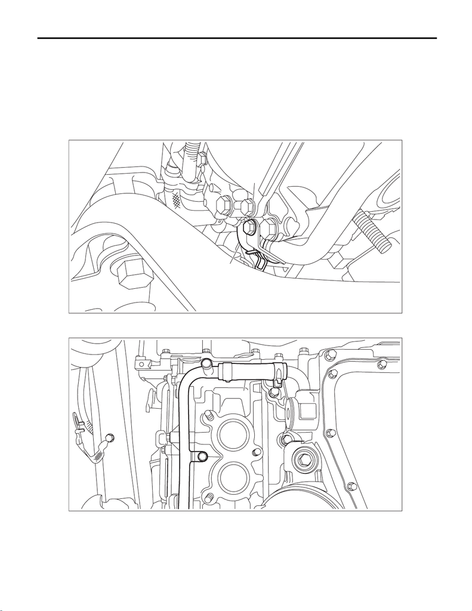

CO(w/o STI)-19

Water Pipe Assembly

COOLING

5. Water Pipe Assembly

A: REMOVAL

1. WATER PIPE ASSEMBLY RH

1) Disconnect the ground terminal from battery sensor. <Ref. to NT-5, BATTERY, NOTE, Note.>

2) Remove the oil pipe assembly. <Ref. to LU(w/o STI)-45, OIL PIPE ASSY, REMOVAL, Oil Pipe.>

3) Remove the front exhaust pipe. <Ref. to EX(w/o STI)-9, REMOVAL, Front Exhaust Pipe.>

4) Disconnect the water hose (A) from the water pipe assembly RH, and remove the bolt (B) securing the wa-

ter pipe assembly RH to the cam carrier RH.

5) Remove the bolt (A) which secures the water pipe assembly RH to the cylinder head RH.

6) Disconnect the water pipe hose RH (B) from oil pan upper, and remove the water pipe assembly RH.

CO-03158

(A)

(B)

CO-03159

(A)

(B)

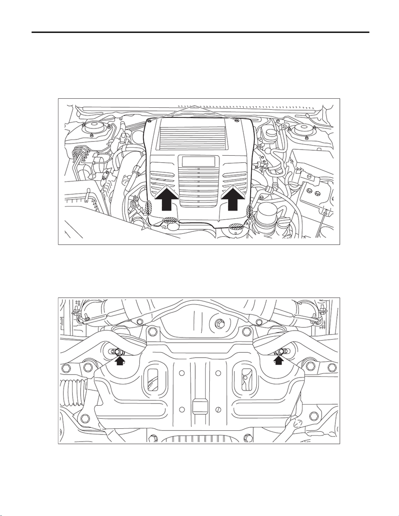

CO(w/o STI)-20

Water Pipe Assembly

COOLING

2. WATER PIPE ASSEMBLY LH

1) Remove the striker - front hood. <Ref. to EB-11, DISASSEMBLY, Front Hood.>

2) Fully open the front hood. <Ref. to NT-20, FRONT HOOD DAMPER STAY, NOTE, Note.>

3) Remove the collector cover.

(1) Remove the clips (A).

(2) Hold the shaded area (B) by hand and carefully pull the RH side (C) upward.

(3) Hold the shaded area (D) by hand and carefully pull the LH side (E) upward.

4) Disconnect the ground terminal from battery sensor. <Ref. to NT-5, BATTERY, NOTE, Note.>

5) Remove the air intake duct. <Ref. to IN(w/o STI)-22, REMOVAL, Air Intake Duct.>

6) Drain engine coolant. <Ref. to CO(w/o STI)-13, DRAINING OF ENGINE COOLANT, REPLACEMENT,

Engine Coolant.>

7) Remove the center exhaust pipe. <Ref. to EX(w/o STI)-35, REMOVAL, Center Exhaust Pipe.>

8) Remove the nuts which secure the engine mounting to the front crossmember.

9) Lower the vehicle.

EX-03204

(A)

(B)

(C)

(E)

(D)

ME-07879

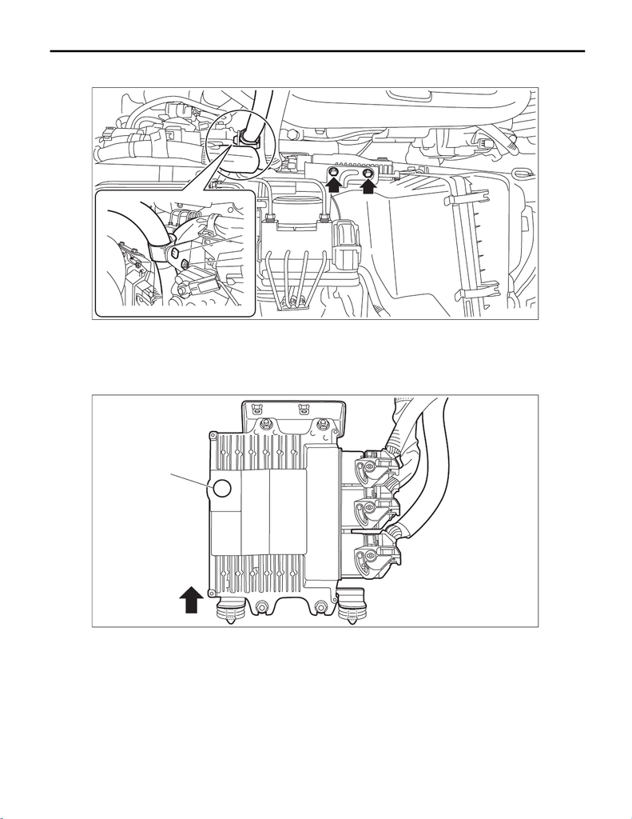

CO(w/o STI)-21

Water Pipe Assembly

COOLING

10) Remove the clips (A) and (B) which secure the engine harness and bulkhead harness to the bracket, and

remove the bolt which secures the engine control module (ECM) to the bracket.

11) Pull out the engine control module (ECM) from the bracket, and move it to a location that does not inter-

fere operation.

NOTE:

When performing the pulling out operation, pay attention not to apply excessive load to the breather filter por-

tion (a) in order to avoid the damage.

12) Remove the intercooler. <Ref. to IN(w/o STI)-38, REMOVAL, Intercooler.>

IN-03579

(B)

(A)

IN-03580

(a)

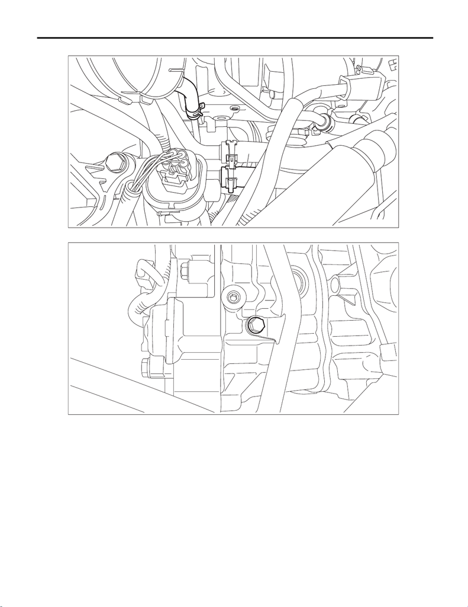

CO(w/o STI)-22

Water Pipe Assembly

COOLING

13) Disconnect the preheater hose (A) and the heater outlet hose (B) from the water pipe assembly LH.

14) Remove the bolt which holds the water pipe assembly LH from the cylinder head LH.

CO-03161

(A)

(B)

CO-03358

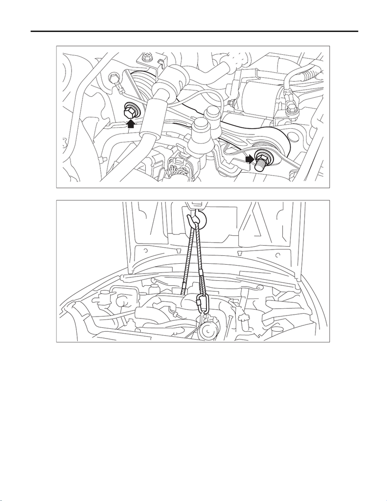

CO(w/o STI)-23

Water Pipe Assembly

COOLING

15) Remove the pitching stopper.

16) Support the engine with a lifting device and wire ropes.

ME-07877

ME-05105

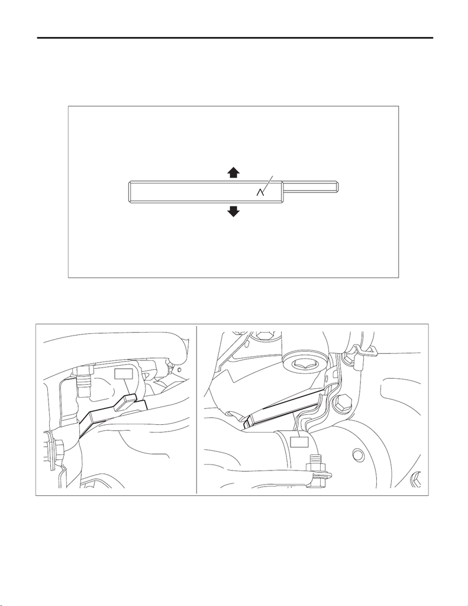

CO(w/o STI)-24

Water Pipe Assembly

COOLING

17) While gradually lifting up the engine, set the ST between the engine mount LH and crossmember, and

then slowly lower the engine.

CAUTION:

• When lifting up the engine, pay attention to the clearance of each part and be careful not to lift the

engine too much, in order to prevent damaging the vehicle.

• To avoid the damage, be sure to set the ST as shown in the figure.

• After lowering the engine, check that the ST does not come off even if the engine is bounced.

ST 18632AA030 STAND ASSY

(A) Direction mark (B) Engine mounting side (C) Crossmember side

ME-07930

(A)

(B)

(C)

ME-07880

ST

ST

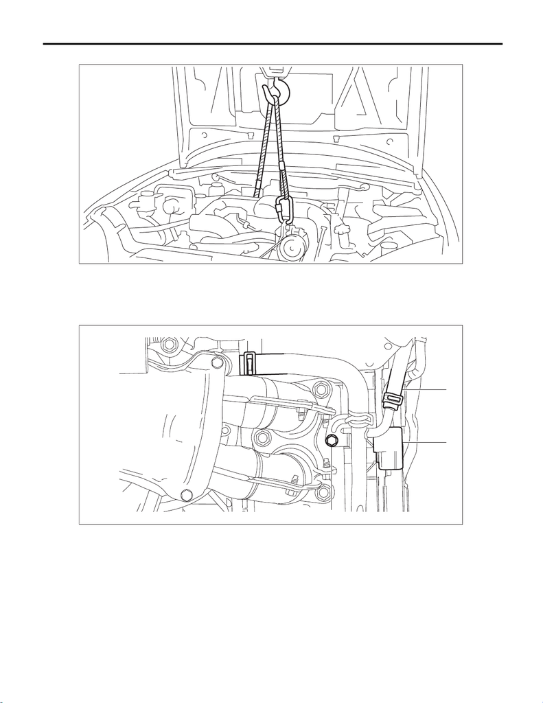

CO(w/o STI)-25

Water Pipe Assembly

COOLING

18) Remove the lifting device and wire ropes.

19) Lift up the vehicle.

20) Remove the rear oxygen sensor connector (A) from the water pipe assembly LH.

21) Disconnect the side engine oil cooler hose B (B) from the water pipe assembly LH.

22) Remove the bolt (C) which secures the water pipe assembly LH to the cylinder head LH.

23) Disconnect the water pipe hose LH (D) from oil pan upper, and remove the water pipe assembly LH.

ME-05105

(A)

(C)

(D)

(B)

CO-03359

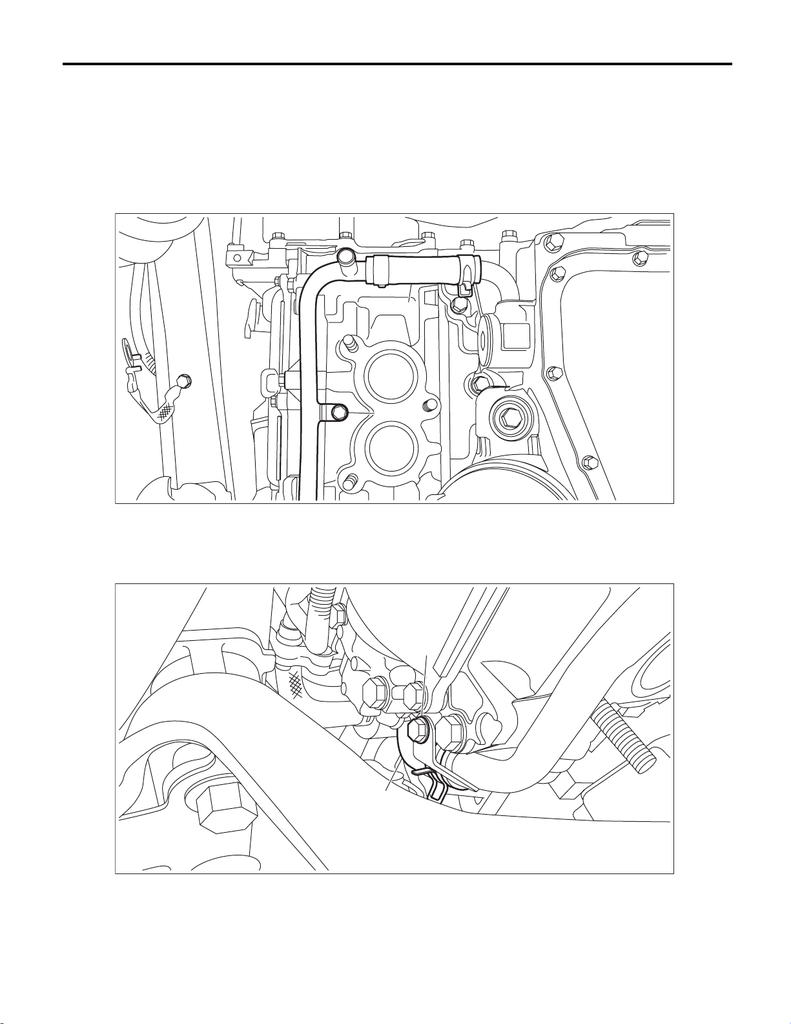

CO(w/o STI)-26

Water Pipe Assembly

COOLING

B: INSTALLATION

1. WATER PIPE ASSEMBLY RH

1) Set the water pipe assembly RH on the engine, and connect the water pipe hose RH (B) to the oil pan up-

per.

2) Install the bolt (A) which secures the water pipe assembly RH to the cylinder head RH.

Tightening torque:

6.4 N·m (0.7 kgf-m, 4.7 ft-lb)

3) Connect the water hose (A) to the water pipe assembly RH, and install the bolt (B) which secures the water

pipe assembly RH to the cam carrier RH.

Tightening torque:

6.4 N·m (0.7 kgf-m, 4.7 ft-lb)

4) Install the front exhaust pipe. <Ref. to EX(w/o STI)-19, INSTALLATION, Front Exhaust Pipe.>

5) Install the oil pipe assembly. <Ref. to LU(w/o STI)-48, OIL PIPE ASSY, INSTALLATION, Oil Pipe.>

6) Connect the ground terminal to battery sensor. <Ref. to NT-5, BATTERY, NOTE, Note.>

7) Fill engine coolant. <Ref. to CO(w/o STI)-14, FILLING OF ENGINE COOLANT, REPLACEMENT, Engine

Coolant.>

CO-03159

(A)

(B)

CO-03158

(A)

(B)

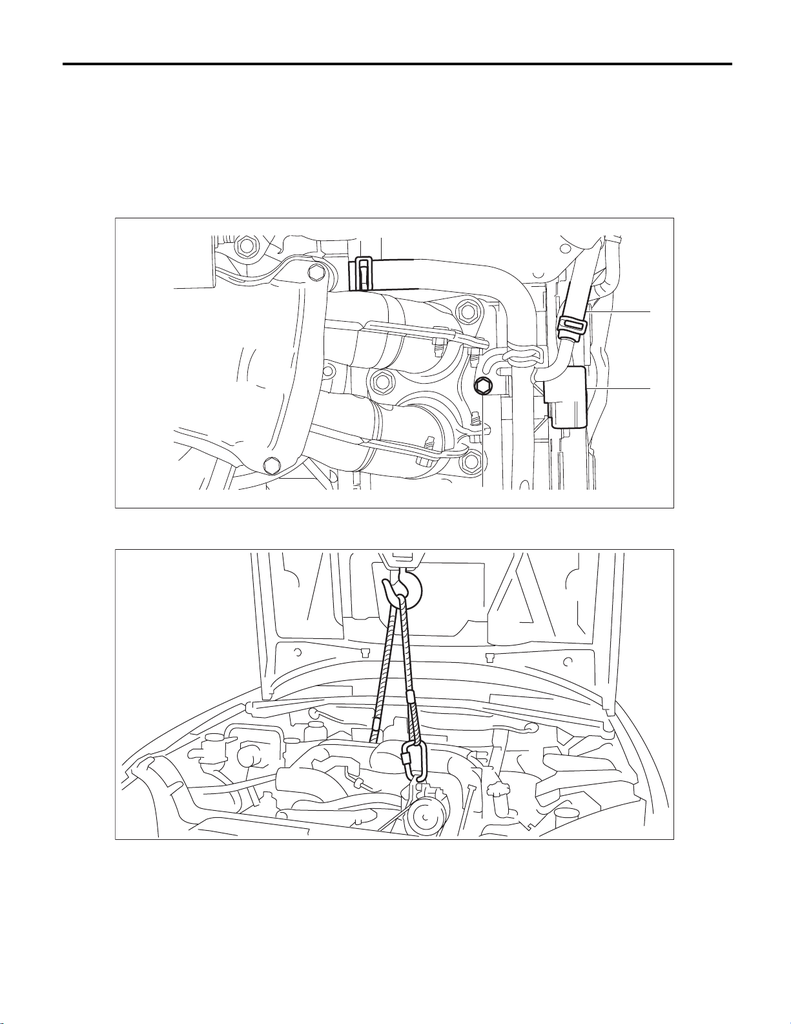

CO(w/o STI)-27

Water Pipe Assembly

COOLING

2. WATER PIPE ASSEMBLY LH

1) Set the water pipe assembly LH on the engine, and connect the water pipe hose LH (D) to the oil pan up-

per.

2) Install the bolt (C) which secures the water pipe assembly LH to the cylinder head LH.

Tightening torque:

6.4 N·m (0.7 kgf-m, 4.7 ft-lb)

3) Connect the side engine oil cooler hose B (B) to the water pipe assembly LH.

4) Install the rear oxygen sensor connector (A) to the water pipe assembly LH.

5) Lower the vehicle.

6) Support the engine with a lifting device and wire ropes.

(A)

(C)

(D)

(B)

CO-03359

ME-05105

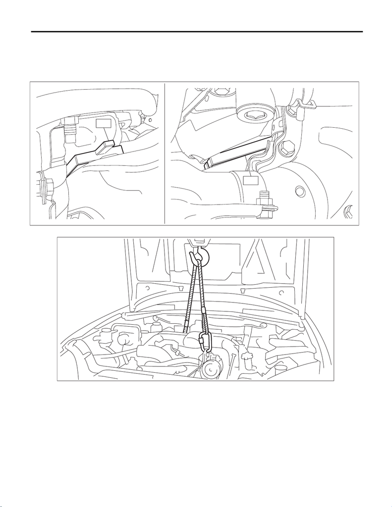

CO(w/o STI)-28

Water Pipe Assembly

COOLING

7) Lift the engine a little, and remove the ST.

CAUTION:

When lifting up the engine, pay attention to the clearance of each part and be careful not to lift the en-

gine too much, in order to prevent damaging the vehicle.

ST 18632AA030 STAND ASSY

8) Lower the engine and remove the lifting device and wire ropes.

ME-07880

ST

ST

ME-05105

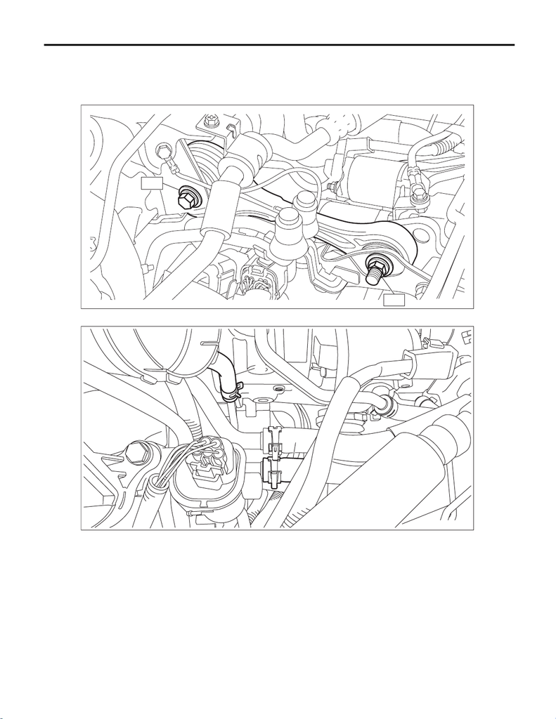

CO(w/o STI)-29

Water Pipe Assembly

COOLING

9) Install the pitching stopper.

Tightening torque:

T1: 50 N·m (5.1 kgf-m, 36.9 ft-lb)

T2: 58 N·m (5.9 kgf-m, 42.8 ft-lb)

10) Connect the preheater hose (A) and the heater outlet hose (B) to the water pipe assembly LH.

ME-07917

T2

T1

CO-03161

(A)

(B)

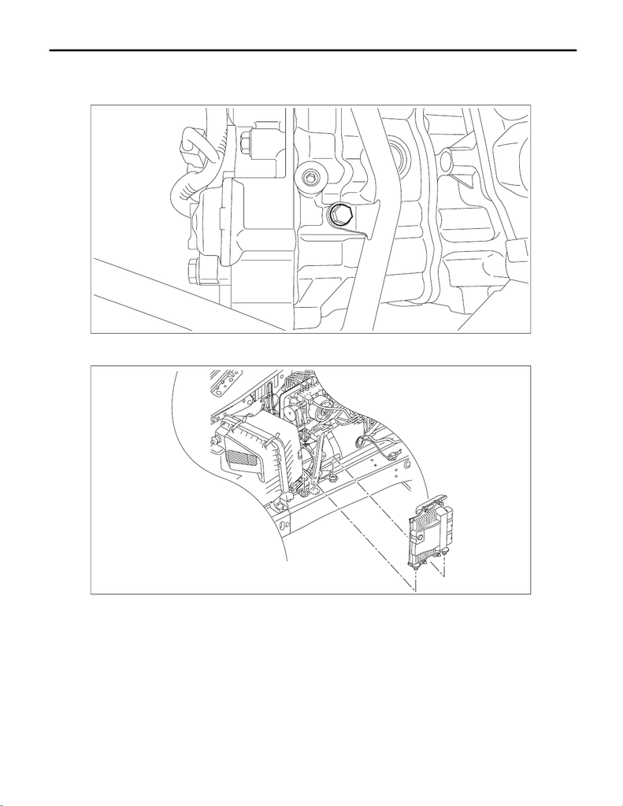

CO(w/o STI)-30

Water Pipe Assembly

COOLING

11) Install the bolt which secures the water pipe assembly LH to the cylinder head LH.

Tightening torque:

6.4 N·m (0.7 kgf-m, 4.7 ft-lb)

12) Install the intercooler. <Ref. to IN(w/o STI)-41, INSTALLATION, Intercooler.>

13) Insert the engine control module (ECM) to the bracket.

CO-03358

FU-08492

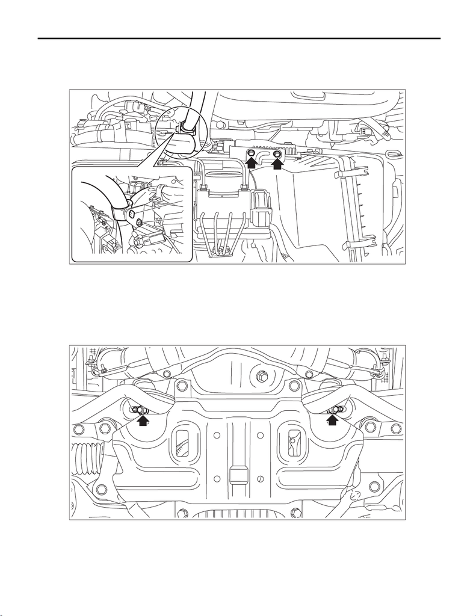

CO(w/o STI)-31

Water Pipe Assembly

COOLING

14) Install the bolt which secures the engine control module (ECM) to the bracket, and then secure the en-

gine harness and bulkhead harness to the bracket with clips (A) and (B).

Tightening torque:

7.5 N·m (0.8 kgf-m, 5.5 ft-lb)

15) Lift up the vehicle.

16) Install the nuts which hold the engine mounting to the crossmember.

NOTE:

• Use a new nut.

• Make sure that locators (a) of the engine mounting are securely inserted.

Tightening torque:

60 N·m (6.1 kgf-m, 44.3 ft-lb)

17) Install the center exhaust pipe. <Ref. to EX(w/o STI)-41, INSTALLATION, Center Exhaust Pipe.>

18) Install the air intake duct. <Ref. to IN(w/o STI)-22, INSTALLATION, Air Intake Duct.>

19) Connect the ground terminal to battery sensor. <Ref. to NT-5, BATTERY, NOTE, Note.>

20) Fill engine coolant. <Ref. to CO(w/o STI)-14, FILLING OF ENGINE COOLANT, REPLACEMENT, En-

gine Coolant.>

21) Install the collector cover.

IN-03579

(B)

(A)

ME-07931

(a)

(a)

[figure not shown]

CO(w/o STI)-32

Water Pipe Assembly

COOLING

22) Set the front hood to the normal position. <Ref. to NT-20, FRONT HOOD DAMPER STAY, NOTE, Note.>

23) Install the striker - front hood. <Ref. to EB-15, ASSEMBLY, Front Hood.>

24) Close the front hood.

C: INSPECTION

1) Check that the water pipe assembly has no deformation, cracks or other damages.

2) Check that the hose has no cracks, damage or loose part.